# Analysis of Length of Growing Season

# Load Libraries

```r
library(tidyverse)
library(readr)

library(CBEPgraphics)
load_cbep_fonts()
```

# Read Data

The frost-free period needs to be derived directly from the daily temperature data. Note that temperature in the source data is in tenths of a degree C.

```r
sibfldnm <- 'Original Data'
parent <- dirname(getwd())
sibling <- paste(parent,sibfldnm, sep = '/')
fn <- 'longdailydata.csv'

longdailydata <- read_csv(paste(sibling,fn, sep = '/')) %>%
  select(-station) %>%
  filter(datatype %in% c('TMAX', 'TMIN')) %>%
  mutate(doy = as.numeric(format(date, format = '%j'))) %>%
  mutate(month = as.numeric(format(date, format = '%m'))) %>%
  mutate(year = as.numeric(format(date, format = '%Y'))) %>%
  mutate(cyear = year - 1980)
```

# Find First and Last Frost Dates

The following strategy was suggested by a Stack Overflow answer here:  
https://stackoverflow.com/questions/41328946/find-last-values-by-condition

In brief, we filter a dataframe down to data that meets our criteria – here, days with temperatures below freezing – and then group_by() to isolate data from each year, and finally slice() to pick the first or last item in the list. Be aware that this strategy depends on the data being in chronological order.

```r
cutoffinF <- 32
cutoffinC <- (cutoffinF - 32) * 5/9

firstfrosts <- longdailydata %>%
  spread(key = datatype, value = value) %>%
  filter(year > 1940) %>%                 # 1940 is an incomplete year in the daily data
  mutate(TMIN = TMIN/10) %>%            # raw data is in tenths of degree C
  filter(TMIN <= cutoffinC) %>%          # Only days below freezing
  filter(month >= 7) %>%                  # only the last half of the year
  group_by(year) %>%
  slice(1)  %>%                         # Choose the first record
  select(date, year, doy)

lastfrosts <- longdailydata %>%
  mutate(TMIN = TMIN/10) %>%            # raw data is in tenths of degree C
  filter(TMIN <= cutoffinC) %>%          # Only days below freezing
  filter(month < 7) %>%                   # only the first half of the year
  group_by(year) %>%
  slice(n())  %>%                       # Choose the last record
  select(date, year, doy)

frosts <- inner_join(firstfrosts,lastfrosts, by = "year", suffix = c('.first', '.last')) %>%
  mutate(frostfree = doy.first - doy.last - 1) # calculate frost-free period

rm(firstfrosts,lastfrosts)
```

# Graphics

Note that as all we fit in this context were simple linear models, we can create graphics using geom_smooth() with method =‘lm’.

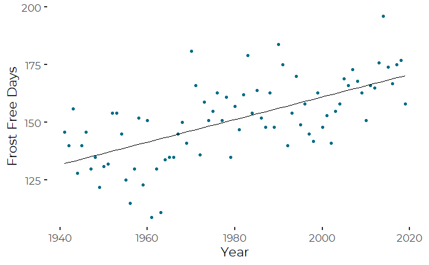

```r
plt <- ggplot(frosts, aes(year, frostfree)) + geom_point(color = cbep_colors()[1]) +
  geom_smooth(method = 'lm', se = FALSE, lty=1, lwd = 0.5, color = 'black') +
  ylab('Frost Free Days') +
  xlab('Year') +
  theme_cbep()
plt
```

# Evaluating Net Changes

```r
the.lm <- lm(frostfree~year, frosts)
nd <- tibble(year = 1945 + seq(0, 70, 10))
(p <- round(predict(the.lm, newdata = nd), 0))
```

```
  1   2   3   4   5   6   7   8
134 139 144 149 154 159 164 168
```

[output not shown]

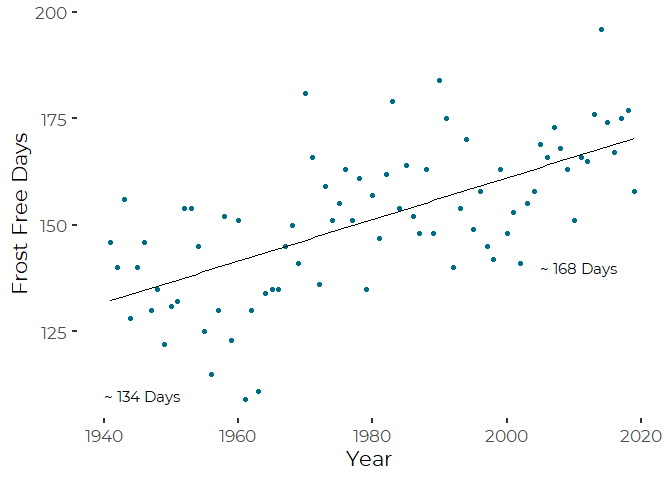

```r
labs = tibble(x = c(1940, 2005),
              y = c(110,140),
              txt = c(paste('~', p[1], 'Days'),
                      paste('~', p[8], 'Days')))

plt + geom_text(aes(x = x, y = y, label = txt), data = labs, hjust = 0)
```

```r
ggsave('FrostFree.png', width = 7, height = 5, type = 'cairo')
ggsave('FrostFree.pdf', width = 7, height = 5, device = cairo_pdf)
#ggsave('FrostFree.svg', width = 7, height = 5)
```

## Show all three indicators

First, reorder the data so we can plot all values on one graphic.

```r
pltdat <- frosts %>%
  select(-date.first, -date.last) %>%
  gather(key = 'indicator', value = 'days', -year) %>%
  mutate(indicator = factor(indicator,
                            levels = c("frostfree", "doy.first", "doy.last"),
                            labels = c("Frost Free Days", "First Frost", "Last Frost")))
```

Then generate Plot. The primary trick here is that I have moved the “strip” for the three facets to the left, to replace what would otherwise be a single Y axis label.

```r
plt1 <- ggplot(pltdat, aes(year, days, color = indicator)) + geom_line(lwd = 1) +
  geom_smooth(method = 'lm', se = FALSE, lty = 2, lwd = 0.5) +
  scale_color_manual(values = cbep_colors(), name = '',
                     labels = c('Frost Free Days', 'First Frost', 'Last Frost')) +

  xlab('Year') +
  ylab(NULL) +

  theme_cbep() +
  theme(legend.position = 'none') +
  theme(panel.spacing = unit(.5, "lines")) +
  theme(strip.background = element_blank(),
        strip.placement = "outside",
        strip.text = element_text(size = 12),
        panel.spacing = unit(0.5, "lines")) +

  facet_wrap('indicator', nrow = 3, scales = 'free_y',
             strip.position = 'left')

plt1

ggsave('frostfreedaysthreeaxes2.png', width = 7, height = 5, units = 'in', type = 'cairo')
```

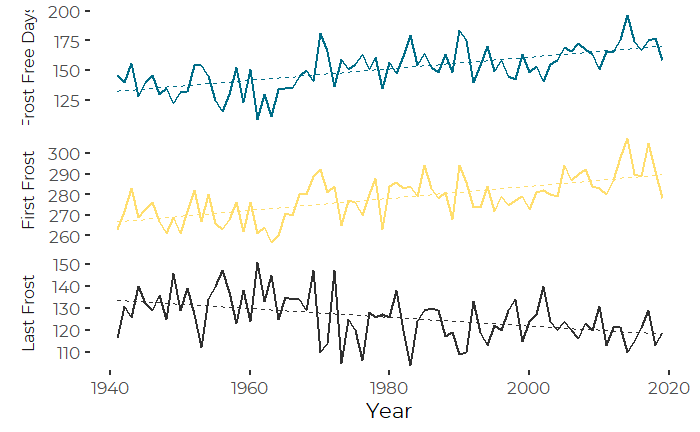

```r
#ggsave('frostfreedaysthreeaxes2.svg', width = 7, height = 5, units = 'in')
ggsave('frostfreedaysthreeaxes2.pdf',
       device = cairo_pdf,
       width = 7, height = 5, units = 'in')
```

## Show the first and last frost dates only

```r
tmp <- frosts %>%
  select(-doy.first, -doy.last, -frostfree) %>%
  gather(key = 'indicator', value = 'date', -year) %>%
  mutate(month = format(date, format = '%m')) %>%
  mutate(day = format(date, format = '%d' )) %>%
  mutate(day = ifelse(day == '29' & month == '02', '28', day)) %>%   # Check for unlikely event of leap day
  mutate(compdate = as.Date(paste(month,day,'2019', sep = '/'), format = '%m/%d/%Y'))
```

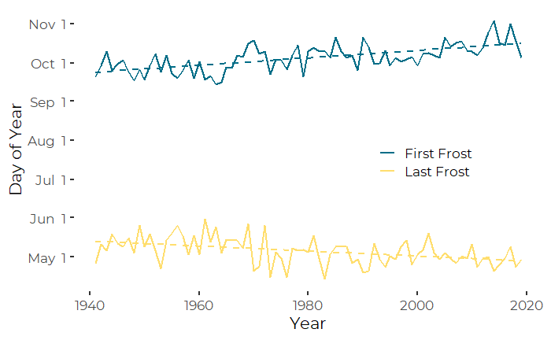

```r
plt <- ggplot(tmp, aes(year, compdate, color=indicator)) + geom_line(lwd = 1) +
  geom_smooth(method = 'lm', se = FALSE, lty = 2) +
  scale_color_manual(values = cbep_colors(), name = '', labels = c('First Frost', 'Last Frost')) +
  xlab('Year') +
  ylab('Day of Year') +
  theme_cbep()

plt +
  scale_y_date(date_breaks = '1 month', date_labels = '%b %e') +
  theme(legend.position = c(0.75,0.5))
```